# Introduction

This notebook is built to help students determine if they are eligible for an admission in their college preferred

## Initial Analysis

We would do the following in the notebook

1. Load and prepare the data
2. Checking out the data with correlation table and plot tables to see which features add more value
3. Analyze various features with graphs to understand which are important and which can be neglected
4. Normalizing the data and getting training and test data
5. Coming up with a tuned model model that would predict the next input

### Libaries that are used

```python
%matplotlib inline
%load_ext autoreload
%autoreload 2
%config InlineBackend.figure_format = 'retina'

import numpy as np
import pandas as pd
import matplotlib.pyplot as plt
import seaborn as sns
```

## Load and prepare the data

A critical step in working with neural networks is preparing the data correctly. Variables on different scales make it difficult for the network to efficiently learn the correct weights. Below, we've written the code to load and prepare the data.

```python
data_path = 'Dataset/Admission_Predict_Ver1.1.csv'

admissions = pd.read_csv(data_path)
```

```python
admissions.head()
```

|  | Serial No. | GRE Score | TOEFL Score | University Rating | SOP | LOR | CGPA | Research | Chance of Admit |
| --- | --- | --- | --- | --- | --- | --- | --- | --- | --- |
| 0 | 1 | 337 | 118 | 4 | 4.5 | 4.5 | 9.65 | 1 | 0.92 |
| 1 | 2 | 324 | 107 | 4 | 4.0 | 4.5 | 8.87 | 1 | 0.76 |
| 2 | 3 | 316 | 104 | 3 | 3.0 | 3.5 | 8.00 | 1 | 0.72 |
| 3 | 4 | 322 | 110 | 3 | 3.5 | 2.5 | 8.67 | 1 | 0.80 |
| 4 | 5 | 314 | 103 | 2 | 2.0 | 3.0 | 8.21 | 0 | 0.65 |

```python
admissions.describe()
```

|  | Serial No. | GRE Score | TOEFL Score | University Rating | SOP | LOR | CGPA | Research | Chance of Admit |
| --- | --- | --- | --- | --- | --- | --- | --- | --- | --- |
| count | 500.000000 | 500.000000 | 500.000000 | 500.000000 | 500.000000 | 500.00000 | 500.000000 | 500.000000 | 500.00000 |
| mean | 250.500000 | 316.472000 | 107.192000 | 3.114000 | 3.374000 | 3.48400 | 8.576440 | 0.560000 | 0.72174 |
| std | 144.481833 | 11.295148 | 6.081868 | 1.143512 | 0.991004 | 0.92545 | 0.604813 | 0.496884 | 0.14114 |
| min | 1.000000 | 290.000000 | 92.000000 | 1.000000 | 1.000000 | 1.00000 | 6.800000 | 0.000000 | 0.34000 |
| 25% | 125.750000 | 308.000000 | 103.000000 | 2.000000 | 2.500000 | 3.00000 | 8.127500 | 0.000000 | 0.63000 |
| 50% | 250.500000 | 317.000000 | 107.000000 | 3.000000 | 3.500000 | 3.50000 | 8.560000 | 1.000000 | 0.72000 |
| 75% | 375.250000 | 325.000000 | 112.000000 | 4.000000 | 4.000000 | 4.00000 | 9.040000 | 1.000000 | 0.82000 |
| max | 500.000000 | 340.000000 | 120.000000 | 5.000000 | 5.000000 | 5.00000 | 9.920000 | 1.000000 | 0.97000 |

## Checking out the data

This dataset has the admission percentage for a university based on various factors like GRE Score, TOEFL Score, University Rankig, SOP, LOR, CGPA and Research. Below is a plot showing the number of students getting admitted just basedon the university ranking

### Correlation Table

Let us draw a correlation table to find out which are the important parameters to consider. Here we can see that the chance of admit is highly correlated with CGPA, GRE and TOEFEL scores are also correlated.

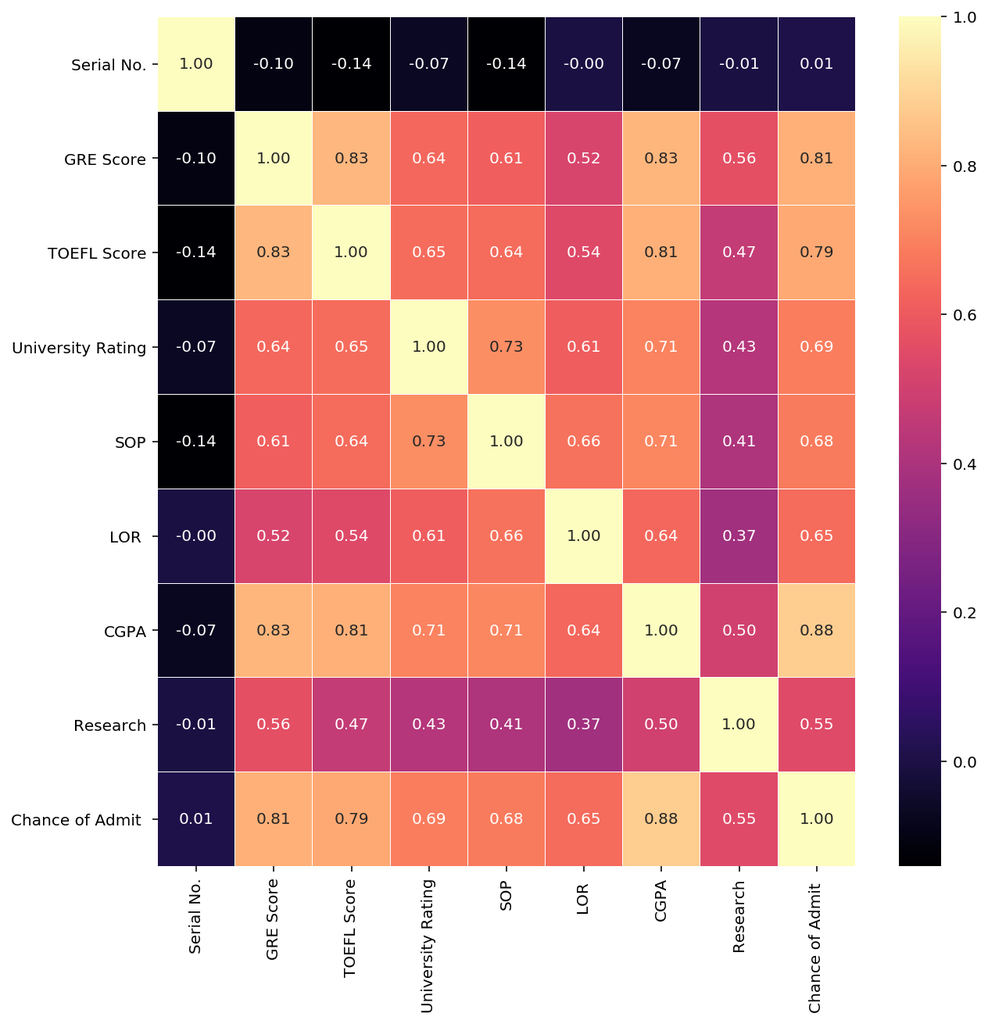

```python
fig,ax = plt.subplots(figsize=(10, 10))
sns.heatmap(admissions.corr(), ax=ax, annot=True, linewidths=0.05, fmt= '.2f',cmap="magma")
plt.show()
```

### Pair plot

The below pair plot indicates that GRE score TOEFL score and CGPA all are linearly related to each other Also it can be inferred that Research Students tend to Score higher by all means

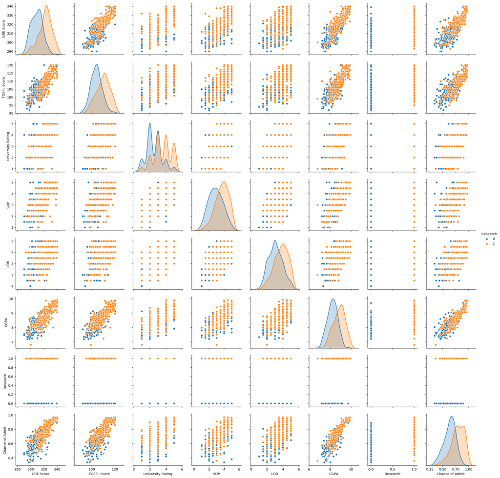

```python
cols=admissions.drop(labels='Serial No.',axis=1)
sns.pairplot(data=cols,hue='Research')
```

### Analyzing TOEFL Scores

Analyzing the lowest, highest and mean TOEFL scores scored by the students

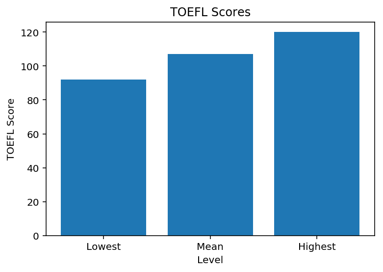

```python
y = np.array([admissions["TOEFL Score"].min(),admissions["TOEFL Score"].mean(),admissions["TOEFL Score"].max()])
x = ["Lowest","Mean","Highest"]
plt.bar(x,y)
plt.title("TOEFL Scores")
plt.xlabel("Level")
plt.ylabel("TOEFL Score")
plt.show()
```

### Analyzing GRE Scores

Analyzing the spread of GRE scores of students

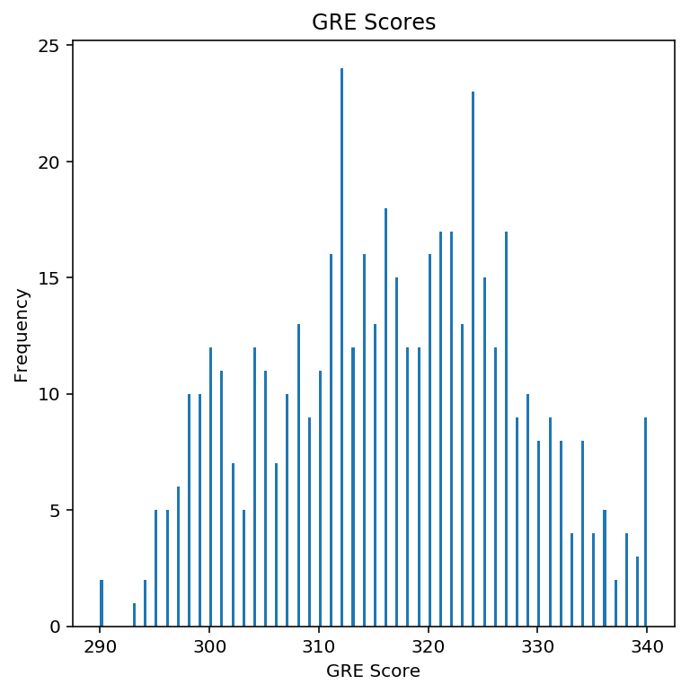

```python
admissions["GRE Score"].plot(kind = 'hist',bins = 200,figsize = (6,6))
plt.title("GRE Scores")
plt.xlabel("GRE Score")
plt.ylabel("Frequency")
plt.show()
```

### Analyzing CGPA

From the below chart, we could understand that the students coming from higher ranked universities have better GPAs

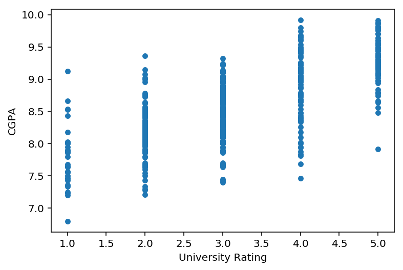

```python
admissions.plot(kind='scatter', x='University Rating', y='CGPA')
```

### Candidates who graduate from good universities have higher percentage of admissions

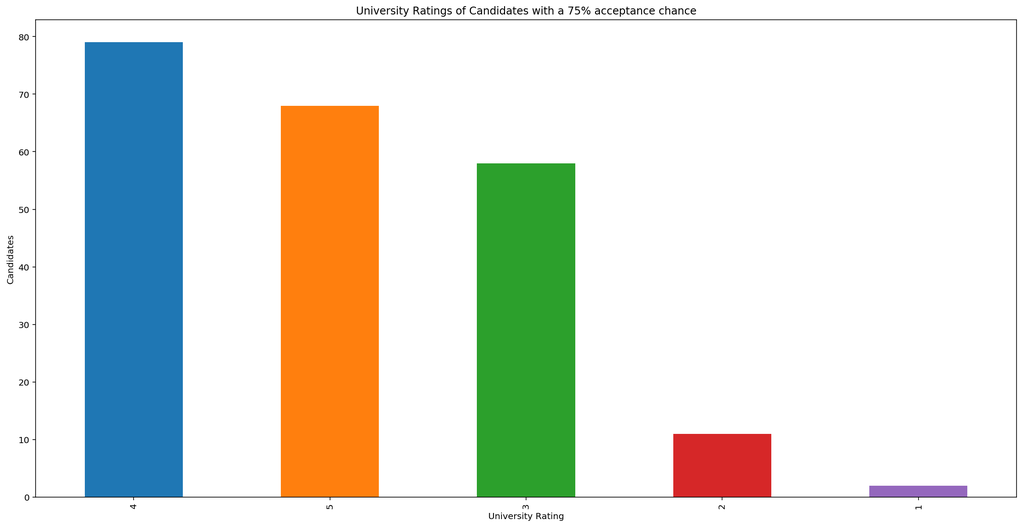

```python
s = admissions[admissions["Chance of Admit "] >= 0.75]["University Rating"].value_counts()
plt.title("University Ratings of Candidates with a 75% acceptance chance")
s.plot(kind='bar',figsize=(20, 10))
plt.xlabel("University Rating")
plt.ylabel("Candidates")
plt.show()
```

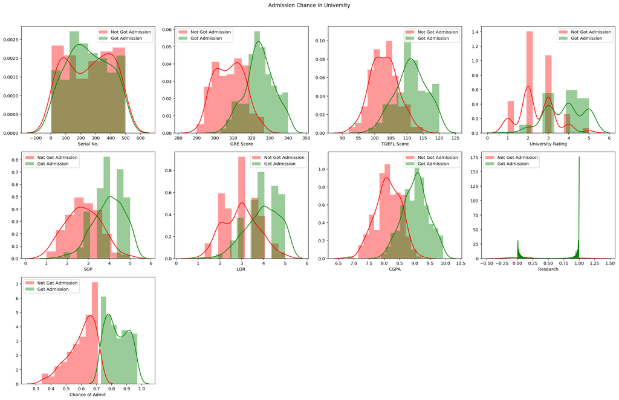

```python
fig = plt.figure(figsize = (20, 25))
j = 0
for i in admissions.columns:
    plt.subplot(6, 4, j+1)
    j += 1
    sns.distplot(admissions[i][admissions['Chance of Admit ']<0.72], color='r', label = 'Not Got Admission')
    sns.distplot(admissions[i][admissions['Chance of Admit ']>0.72], color='g', label = 'Got Admission')
    plt.legend(loc='best')
fig.suptitle('Admission Chance In University ')
fig.tight_layout()
fig.subplots_adjust(top=0.95)
plt.show()
```

### One hot encoding

Here we have some categorical variables like University Rankig and Research. To include these in our model, we'll need to make binary dummy variables (or do one-hot encoding). This is simple to do with Pandas thanks to `get_dummies()`.

```python
dummy_fields = ['University Rating', 'Research']
one_hot_admissions = admissions[:]
for each in dummy_fields:
    dummies = pd.get_dummies(one_hot_admissions[each], prefix=each, drop_first=False)
    one_hot_admissions = pd.concat([one_hot_admissions, dummies], axis=1)

to_be_dropped = ['University Rating', 'Research', 'Serial No.']
one_hot_admissions = one_hot_admissions.drop(to_be_dropped, axis=1)
one_hot_admissions.head()
```

|  | GRE Score | TOEFL Score | SOP | LOR | CGPA | Chance of Admit | University Rating_1 | University Rating_2 | University Rating_3 | University Rating_4 | University Rating_5 | Research_0 | Research_1 |
| --- | --- | --- | --- | --- | --- | --- | --- | --- | --- | --- | --- | --- | --- |
| 0 | 337 | 118 | 4.5 | 4.5 | 9.65 | 0.92 | 0 | 0 | 0 | 1 | 0 | 0 | 1 |
| 1 | 324 | 107 | 4.0 | 4.5 | 8.87 | 0.76 | 0 | 0 | 0 | 1 | 0 | 0 | 1 |
| 2 | 316 | 104 | 3.0 | 3.5 | 8.00 | 0.72 | 0 | 0 | 1 | 0 | 0 | 0 | 1 |
| 3 | 322 | 110 | 3.5 | 2.5 | 8.67 | 0.80 | 0 | 0 | 1 | 0 | 0 | 0 | 1 |
| 4 | 314 | 103 | 2.0 | 3.0 | 8.21 | 0.65 | 0 | 1 | 0 | 0 | 0 | 1 | 0 |

### Normalizing the variables

We could normalize variables like GRE, TOEFL, SOP, LOR and CGPA

```python
processed_data = one_hot_admissions[:]

processed_data = processed_data/processed_data.max()
#processed_data = (processed_data - np.min(processed_data)) / (np.max(processed_data) - np.min(processed_data))
```

### Splitting the data into training, testing, and validation sets

```python
"""
sample = np.random.choice(processed_data.index, size=int(len(processed_data)*0.9), replace=False)
train_data, test_data = processed_data.iloc[sample], processed_data.drop(sample)

print("Number of training samples is", len(train_data))
print("Number of testing samples is", len(test_data))
print(train_data.shape[1])
#print(test_data[:10])

train_features = train_data.drop('Chance of Admit ', axis=1)
train_targets = train_data['Chance of Admit '].values
test_features = test_data.drop('Chance of Admit ', axis=1)
test_targets =  test_data['Chance of Admit '].values
"""
```

[output not shown]

### Splitting the data into features and targets

```python
train_features = processed_data.drop('Chance of Admit ', axis=1)
train_targets = processed_data['Chance of Admit '].values

###This is another option####
from sklearn.model_selection import train_test_split
train_features,test_features,train_targets,test_targets = train_test_split(train_features,train_targets,test_size = 0.20,random_state = 42)
```

## Finally we have prepared our data. Now it's time to train it with neural nets !!!

```python
# Imports
import numpy as np
from keras.models import Sequential
from keras.layers.core import Dense, Dropout, Activation
from keras.optimizers import SGD
from keras.utils import np_utils

# Building the model
model = Sequential()
model.add(Dense(64, activation='relu', input_shape=(train_features.shape[1],)))
model.add(Dense(32, activation='relu'))
model.add(Dense(1, activation='sigmoid'))

# Compiling the model
model.compile(loss = 'mean_squared_error', optimizer='adam', metrics=['mse', 'mae'])
model.summary()
```

```
_________________________________________________________________
Layer (type)                 Output Shape              Param #
=================================================================
dense_4 (Dense)              (None, 64)                832
_________________________________________________________________
dense_5 (Dense)              (None, 32)                2080
_________________________________________________________________
dense_6 (Dense)              (None, 1)                 33
=================================================================
Total params: 2,945
Trainable params: 2,945
Non-trainable params: 0
_________________________________________________________________
```

## Training the model

```python
# Training the model
history = model.fit(train_features, train_targets, validation_split=0.2, epochs=100, batch_size=8, verbose=0)
```

## Evaluating the model

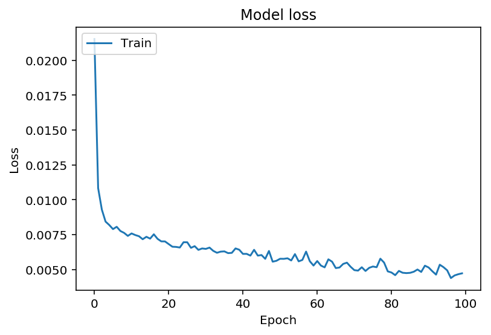

```python
#print(vars(history))
plt.plot(history.history['loss'])

plt.title('Model loss')
plt.ylabel('Loss')
plt.xlabel('Epoch')
plt.legend(['Train', 'Test'], loc='upper left')
plt.show()
```

```python
# Evaluating the model on the training and testing set
score = model.evaluate(train_features, train_targets)
print("score: ", score)
print("\n Training Accuracy:", score)
score = model.evaluate(test_features, test_targets)
print("score: ", score)
print("\n Testing Accuracy:", score)
```

```
score:  [0.00540523137897253, 0.00540523137897253, 0.05910135880112648]

 Training Accuracy: [0.00540523137897253, 0.00540523137897253, 0.05910135880112648]
score:  [0.004537396309897304, 0.004537396309897304, 0.05288841187953949]

 Testing Accuracy: [0.004537396309897304, 0.004537396309897304, 0.05288841187953949]
```

## Prediction vs original labels

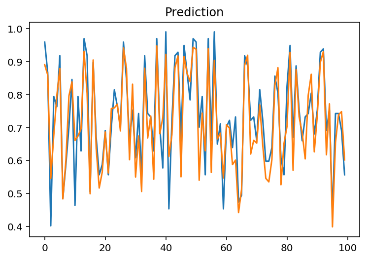

```python
y_pred = model.predict(test_features)
plt.plot(test_targets)
plt.plot(y_pred)
plt.title('Prediction')
```

### Useful Info taken from other pages

```python
# reading the dataset
df = pd.read_csv(data_path)

# it may be needed in the future.
serialNo = df["Serial No."].values

df.drop(["Serial No."],axis=1,inplace = True)

df=df.rename(columns = {'Chance of Admit ':'Chance of Admit'})
```

```python
X=df.drop('Chance of Admit',axis=1)
y=df['Chance of Admit']
```

```python
from sklearn.model_selection import train_test_split
from sklearn import preprocessing

#Normalisation works slightly better for Regression.
X_norm=preprocessing.normalize(X)
X_train,X_test,y_train,y_test=train_test_split(X_norm,y,test_size=0.20,random_state=101)
```

```python
from sklearn.linear_model import LinearRegression,LogisticRegression
from sklearn.tree import DecisionTreeRegressor,DecisionTreeClassifier
from sklearn.ensemble import RandomForestRegressor,RandomForestClassifier
from sklearn.ensemble import GradientBoostingRegressor,GradientBoostingClassifier
from sklearn.ensemble import AdaBoostRegressor,AdaBoostClassifier
from sklearn.ensemble import ExtraTreesRegressor,ExtraTreesClassifier
from sklearn.neighbors import KNeighborsRegressor,KNeighborsClassifier
from sklearn.svm import SVR,SVC
from sklearn.naive_bayes import GaussianNB

from sklearn.metrics import accuracy_score,mean_squared_error
```

## Regression techniques

```python
regressors=[['Linear Regression :',LinearRegression()],
       ['Decision Tree Regression :',DecisionTreeRegressor()],
       ['Random Forest Regression :',RandomForestRegressor()],
       ['Gradient Boosting Regression :', GradientBoostingRegressor()],
       ['Ada Boosting Regression :',AdaBoostRegressor()],
       ['Extra Tree Regression :', ExtraTreesRegressor()],
       ['K-Neighbors Regression :',KNeighborsRegressor()],
       ['Support Vector Regression :',SVR()]]
reg_pred=[]
print('Results...\n')
for name,model in regressors:
    model=model
    model.fit(X_train,y_train)
    predictions = model.predict(X_test)
    rms=np.sqrt(mean_squared_error(y_test, predictions))
    reg_pred.append(rms)
    print(name,rms)
```

```
Results...

Linear Regression : 0.07765759656302856
Decision Tree Regression : 0.10634378214075328
Random Forest Regression : 0.08262396746707337
Gradient Boosting Regression : 0.07717585272342939
Ada Boosting Regression : 0.08517057499316942
Extra Tree Regression : 0.07978709168781627
K-Neighbors Regression : 0.08882567196480981
Support Vector Regression : 0.12852063446226347
```

```python
y_ax=['Linear Regression' ,'Decision Tree Regression', 'Random Forest Regression','Gradient Boosting Regression', 'Ada Boosting Regression','Extra Tree Regression' ,'K-Neighbors Regression', 'Support Vector Regression' ]
x_ax=reg_pred
```

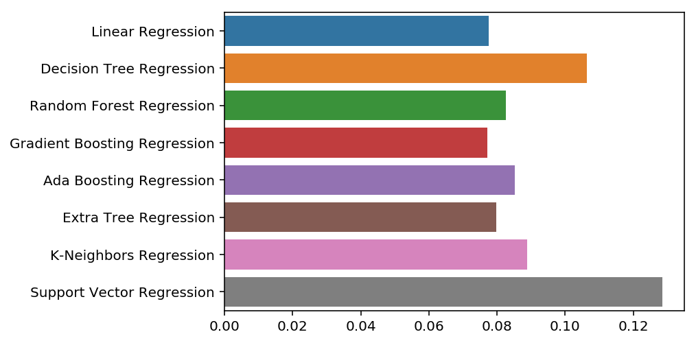

```python
sns.barplot(x=x_ax,y=y_ax)
```

## Classification Techniques

```python
from sklearn.model_selection import train_test_split

X_train,X_test,y_train,y_test=train_test_split(X,y,test_size=0.20,random_state=101)
```

```python
#If Chance of Admit greater than 80% we classify it as 1
y_train_c = [1 if each > 0.8 else 0 for each in y_train]
y_test_c  = [1 if each > 0.8 else 0 for each in y_test]
```

```python
classifiers=[['Logistic Regression :',LogisticRegression()],
       ['Decision Tree Classification :',DecisionTreeClassifier()],
       ['Random Forest Classification :',RandomForestClassifier()],
       ['Gradient Boosting Classification :', GradientBoostingClassifier()],
       ['Ada Boosting Classification :',AdaBoostClassifier()],
       ['Extra Tree Classification :', ExtraTreesClassifier()],
       ['K-Neighbors Classification :',KNeighborsClassifier()],
       ['Support Vector Classification :',SVC()],
       ['Gausian Naive Bayes :',GaussianNB()]]
cla_pred=[]
for name,model in classifiers:
    model=model
    model.fit(X_train,y_train_c)
    predictions = model.predict(X_test)
    cla_pred.append(accuracy_score(y_test_c,predictions))
    print(name,accuracy_score(y_test_c,predictions))
```

```
Logistic Regression : 0.89
Decision Tree Classification : 0.91
Random Forest Classification : 0.89
Gradient Boosting Classification : 0.9
Ada Boosting Classification : 0.9
Extra Tree Classification : 0.92
K-Neighbors Classification : 0.84
Support Vector Classification : 0.9
Gausian Naive Bayes : 0.89
```

```python
y_ax=['Logistic Regression' ,
      'Decision Tree Classifier',
      'Random Forest Classifier',
      'Gradient Boosting Classifier',
      'Ada Boosting Classifier',
      'Extra Tree Classifier' ,
      'K-Neighbors Classifier',
      'Support Vector Classifier',
       'Gaussian Naive Bayes']
x_ax=cla_pred
```

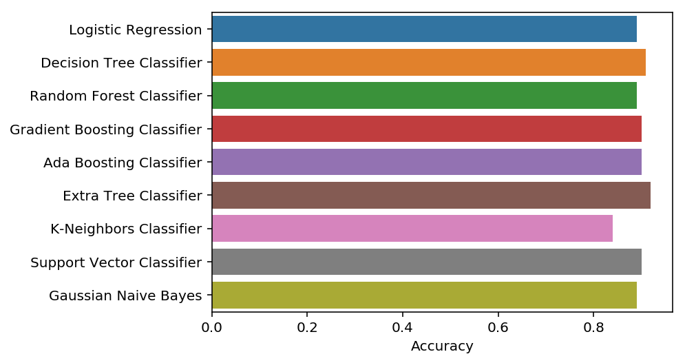

```python
sns.barplot(x=x_ax,y=y_ax)
plt.xlabel('Accuracy')
```